# COVID-19 vaccine effectiveness in two Colombian cities

A target trial emulation on linked national registries

Author

Carlos Alberto Reina Bolaños, PhD

Published

September 24, 2026

**NoteReproducibility**

Every figure and number on this page was produced by the code in this repository, run on **synthetic data** generated by `R/01_simulate_data.R`. The original analysis used individual-level records from the national immunisation registry, the national surveillance system and vital statistics, which are held under a data use agreement and are not distributed here. The synthetic data reproduce the structure, categories, missingness and confounding of that extract, with a known true vaccine effectiveness of 55% built in, so the pipeline can be validated end to end.

The numbers below are therefore a demonstration that the analysis recovers what it should, not study findings.

## The causal question

Among residents of Cali and Montería who became eligible for vaccination under Colombia’s National Vaccination Plan, what would the risk of SARS-CoV-2 infection, hospitalisation and death have been had everyone completed the primary vaccination schedule, compared with had no one been vaccinated?

## Target trial protocol

| Component | Specification |
| --- | --- |
| **Eligibility** | Residents of Cali or Montería registered in the national vaccination and surveillance registries, eligible for vaccination under the National Vaccination Plan between 17 Feb 2021 and 30 Jun 2022 |
| **Treatment strategies** | (1) Complete the primary schedule: two doses 14–28 days apart. (2) Remain unvaccinated |
| **Assignment** | Observational; addressed by exact matching within risk sets |
| **Time zero** | Vaccinated: second dose + 14 days. Unvaccinated: the day their priority group became eligible |
| **Outcomes** | Laboratory-confirmed infection; hospitalisation; death |
| **Follow-up** | From time zero to the outcome, 360 days, or 30 June 2022, whichever came first |
| **Causal contrast** | Per-protocol effect of completing the primary schedule |
| **Analysis** | Cox proportional hazards stratified by matched pair; effectiveness = 1 − HR |

### Two design decisions that drive the result

**Time zero for the unvaccinated.** Colombia’s priority schedule opened vaccination to age and comorbidity groups on fixed calendar dates. That gives every person an eligibility date determined at baseline, which does not depend on their own later decisions, and which serves as the start of unexposed follow-up.

**Exposure is time-varying.** Rather than defining the comparison group as people who were never vaccinated during the whole study period — which conditions group membership on future behaviour — every person contributes unexposed person-time until they are vaccinated. The comparison is between person-time under two strategies, not between two types of person.

## Cohort

| Quantity | Value |
| --- | --- |
| Individuals in the source extract | 58,997 |
| Person-time intervals, whole cohort | 83,883 |
| unexposed | 58,941 |
| exposed | 24,942 |
| Matched pairs | 23,671 |
| Median follow-up in matched pairs, days | 122 |

### Baseline characteristics

Matching was exact on city, sex, age group, comorbidity group and insurance scheme, so the two columns agree by construction on those variables.

| Characteristic | Complete primary schedule | Unvaccinated |
| --- | --- | --- |
| Individuals | 23,671 | 23,671 |
| Age, years, median (IQR) | 39 (27-53) | 39 (27-53) |
| Age group |  |  |
| 3-11 | 516 (2.2%) | 516 (2.2%) |
| 12-25 | 4649 (19.6%) | 4649 (19.6%) |
| 26-39 | 7024 (29.7%) | 7024 (29.7%) |
| 40-49 | 4254 (18.0%) | 4254 (18.0%) |
| 50-59 | 3024 (12.8%) | 3024 (12.8%) |
| >=60 | 4204 (17.8%) | 4204 (17.8%) |
| Sex |  |  |
| F | 12442 (52.6%) | 12442 (52.6%) |
| M | 11157 (47.1%) | 11157 (47.1%) |
| Missing | 72 (0.3%) | 72 (0.3%) |
| City |  |  |
| 76001 - Cali | 17249 (72.9%) | 17249 (72.9%) |
| 23001 - Montería | 6422 (27.1%) | 6422 (27.1%) |
| Comorbidity group |  |  |
| 1. None | 17443 (73.7%) | 17443 (73.7%) |
| 2. Other | 1036 (4.4%) | 1036 (4.4%) |
| 3. Cardiometabolic + other | 413 (1.7%) | 413 (1.7%) |
| 4. Cardiometabolic | 4779 (20.2%) | 4779 (20.2%) |
| Insurance scheme |  |  |
| Contributivo | 12623 (53.3%) | 12623 (53.3%) |
| Especial | 1178 (5.0%) | 1178 (5.0%) |
| Excepcion | 413 (1.7%) | 413 (1.7%) |
| Subsidiado | 9049 (38.2%) | 9049 (38.2%) |
| Missing | 408 (1.7%) | 408 (1.7%) |
| Follow-up, days, median (IQR) | 126 (65-197) | 118 (59-185) |
| Confirmed infections | 1248 (5.3%) | 2754 (11.6%) |

### Covariate balance

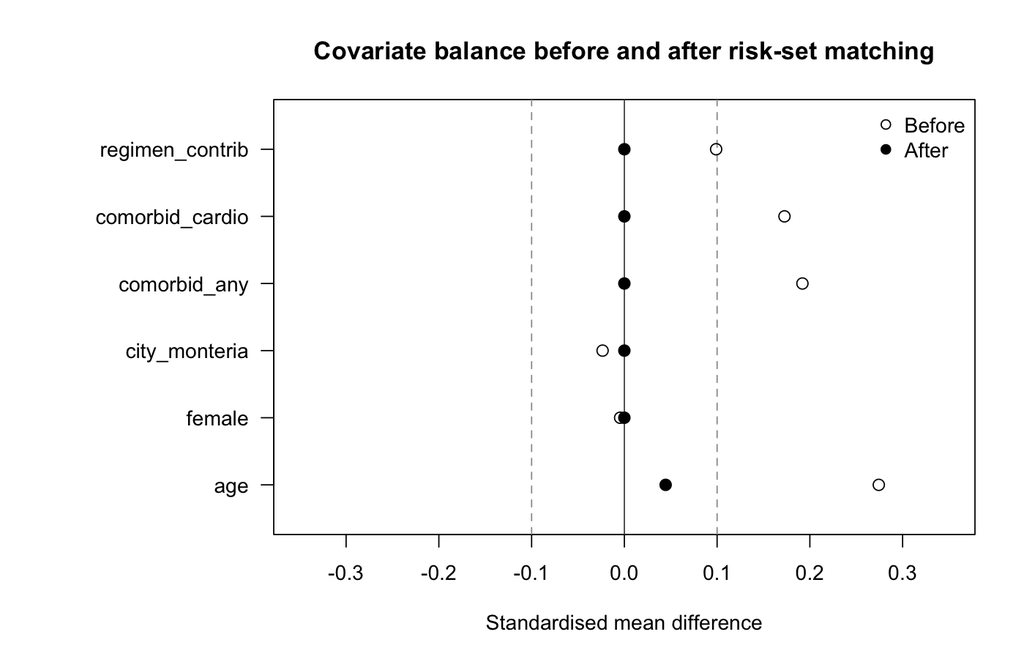

Standardised mean differences before and after risk-set matching

## Results

| Outcome | Events | Vaccine effectiveness |
| --- | --- | --- |
| Confirmed infection | 4002 | 57.4% (95% CI 54.3 to 60.3) |
| Hospitalisation | 201 | 84.3% (95% CI 76.3 to 89.6) |
| Death | 75 | 87.7% (95% CI 74.3 to 94.1) |

### By follow-up window

Person-time is truncated at the end of each window, not only the event indicator, so each row is a risk over that window rather than a mixture.

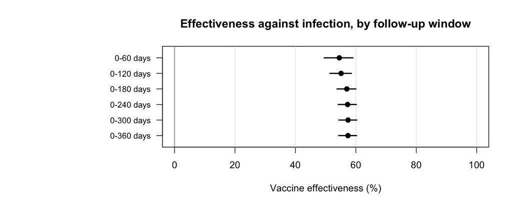

Effectiveness against infection by follow-up window

### By subgroup

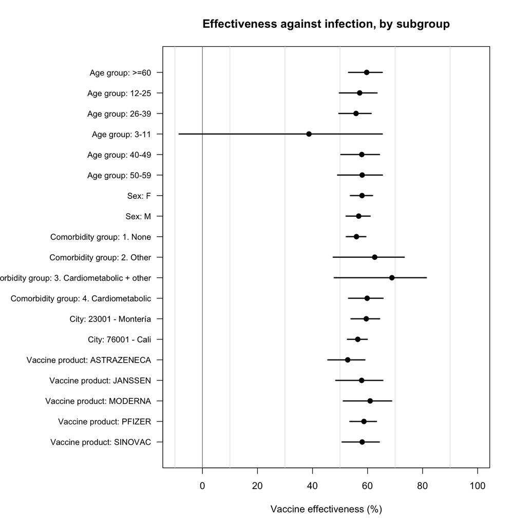

Effectiveness against infection by subgroup

## Diagnostics and sensitivity analyses

### Proportional hazards

```
        chisq df    p
exposed   1.2  1 0.27
GLOBAL    1.2  1 0.27
```

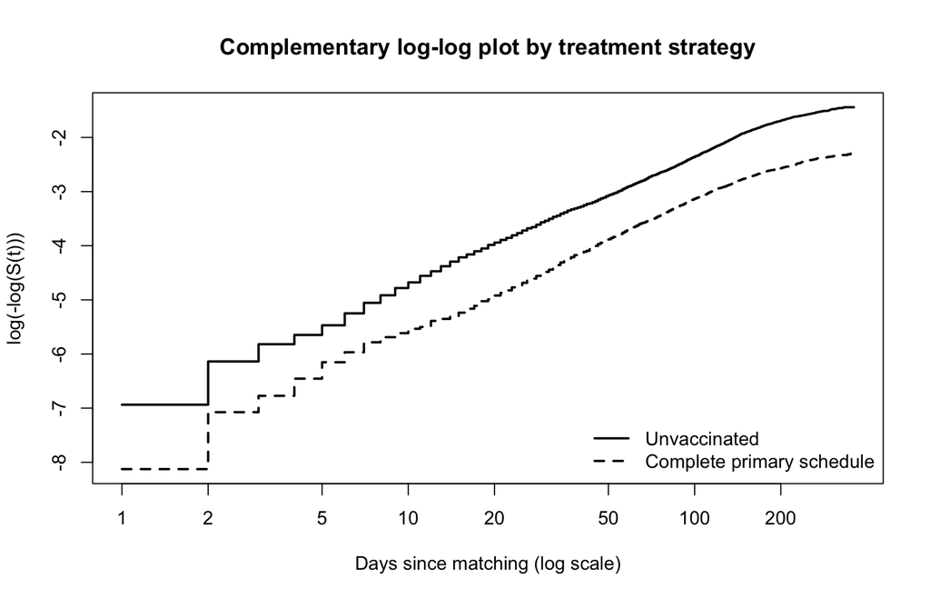

Complementary log-log plot by treatment strategy

### How much the design matters

The same data, analysed four ways that differ only in how time zero and the comparison group are defined. The true effectiveness built into the synthetic data is 55%.

| Design | Vaccine effectiveness |
| --- | --- |
| Risk-set matched (primary) | 57.4% (95% CI 54.3 to 60.3) |
| Whole cohort, time-varying, calendar time | 55.7% (95% CI 53.3 to 58.0) |
| Whole cohort, time since individual origin | 63.0% (95% CI 61.1 to 64.8) |
| Never-vaccinated comparison (original) | 70.6% (95% CI 69.0 to 72.1) |

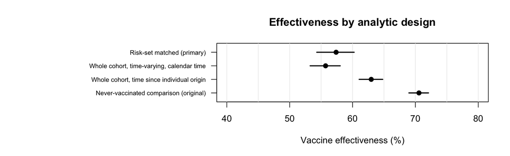

Effectiveness by analytic design

The two designs that align exposed and unexposed person-time in calendar time recover the true value. Measuring time from each individual’s own origin compares person-time from different phases of the epidemic and overstates effectiveness; restricting the comparison group to people who were never vaccinated at any point compounds the problem.

### Unmeasured confounding

```
E-value for the point estimate:      2.43
E-value for the confidence limit:    2.32

An unmeasured confounder would have to be associated with both vaccination and
infection by a risk ratio of at least 2.43, beyond the matched covariates, to
explain away the estimate.
```

## Limitations

Stated plainly rather than buried. Outcome ascertainment depends on testing, which varied over time and between the two cities; differential testing by vaccination status would bias effectiveness against infection, though it should affect hospitalisation and death much less. Matching is exact on the recorded covariates only, and occupation, previous infection and household exposure are not recorded in these registries. Severe outcomes are dated at symptom onset rather than at admission. Follow-up ends before the period in which boosters became widespread, so these estimates describe the primary schedule alone.

## Reproducing this analysis

```r
git clone https://github.com/carlosreina-epi/covid19-vaccine-effectiveness-colombia.git
cd covid19-vaccine-effectiveness-colombia
Rscript R/01_simulate_data.R
Rscript R/02_build_cohort.R
Rscript R/03_match.R
Rscript R/04_table1.R
Rscript R/05_models.R
Rscript R/06_diagnostics.R
quarto render
```

The pipeline needs R with the `survival` package; everything else is base R.

```
R version 4.5.1 (2025-06-13)
```

```
Platform: x86_64-apple-darwin20
```

```
survival: 3.8.3
```